# IODS course project

### Golden standardisation and tracking phenomenon

```r
RATSS <- RATSL %>%
  group_by(Group,ID) %>%
  mutate(stdweight = ((Weight-mean(Weight))/sd(Weight))) %>%
  ungroup()

str(RATSS)
```

```
## tibble [176 x 6] (S3: tbl_df/tbl/data.frame)
##  $ ID       : Factor w/ 16 levels "1","2","3","4",..: 1 2 3 4 5 6 7 8 9 10 ...
##  $ Group    : Factor w/ 3 levels "1","2","3": 1 1 1 1 1 1 1 1 2 2 ...
##  $ WD       : chr [1:176] "WD1" "WD1" "WD1" "WD1" ...
##  $ Weight   : int [1:176] 240 225 245 260 255 260 275 245 410 405 ...
##  $ Time     : int [1:176] 1 1 1 1 1 1 1 1 1 1 ...
##  $ stdweight: num [1:176] -2.025 -1.735 -1.768 -0.902 -1.636 ...
```

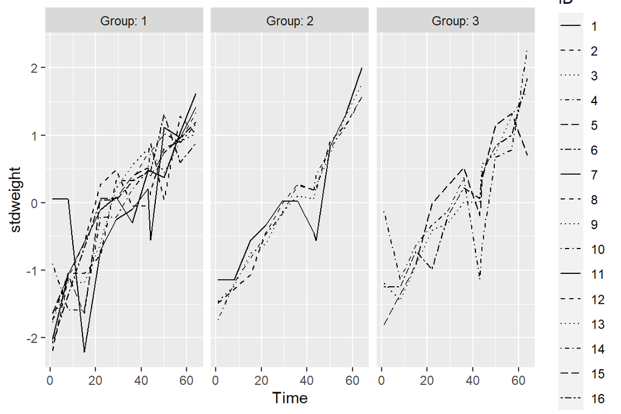

```r
ggplot(RATSS, aes(x = Time, y = stdweight, linetype = ID)) +
  geom_line() +
  scale_linetype_manual(values = rep(1:10, times=4)) +
  facet_grid(. ~ Group, labeller = label_both) +
  scale_y_continuous(limits = c(min(RATSS$stdweight), max(RATSS$stdweight)))
```

```r
#Getting the total number of time points per animal
n <- RATSS$Time %>% unique() %>% length()

#summary data with mean and standard error
RATSS <- RATSL %>%
  group_by(Group,Time) %>%
  summarise(mean = mean(Weight), se = (sd(Weight))/(sqrt(n)) ) %>%
  ungroup()
# Glimpse the data
glimpse(RATSS)
```

```
## Rows: 33
## Columns: 4
## $ Group <fct> 1, 1, 1, 1, 1, 1, 1, 1, 1, 1, 1, 2, 2, 2, 2, 2, 2, 2, 2, 2, 2...
## $ Time  <int> 1, 8, 15, 22, 29, 36, 43, 44, 50, 57, 64, 1, 8, 15, 22, 29, 3...
## $ mean  <dbl> 250.625, 255.000, 254.375, 261.875, 264.625, 265.000, 267.375...
## $ se    <dbl> 4.589478, 3.947710, 3.460116, 4.100800, 3.333956, 3.552939, 3...
```

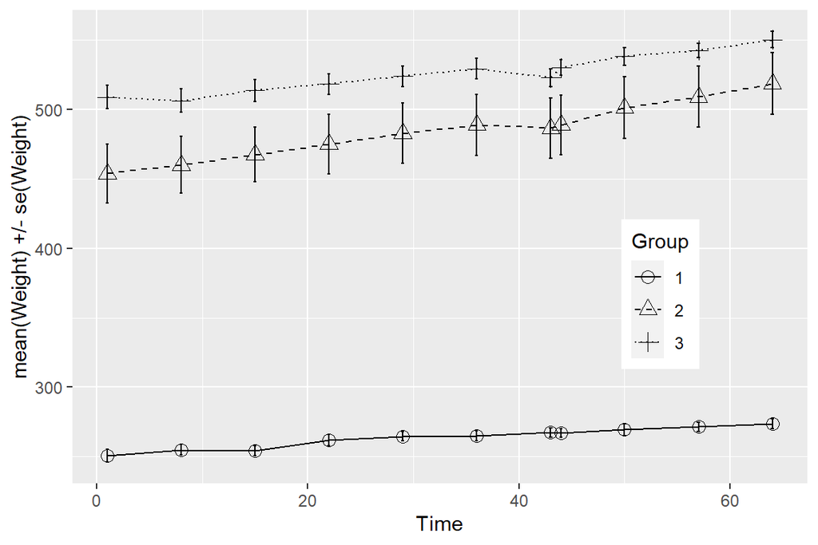

```r
ggplot(RATSS, aes(x = Time, y = mean, linetype = Group, shape = Group)) +
  geom_line()+
  scale_linetype_manual(values = c(1,2,3)) +
  geom_point(size=3)+
  scale_shape_manual(values = c(1,2,3))+
  geom_errorbar(aes(ymin = mean - se, ymax = mean + se, linetype="1"), width=0.3)+
  theme(legend.position = c(0.8,0.4))+
  scale_y_continuous(name = "mean(Weight) +/- se(Weight)")
```

The summary of the weight shows that there is a general increase in weight for all three groups. However, the SE for group 2 is large, which may suggest that there is no significant increased in weight for all different timepoints of group 2. The same can be said for group 3 to a smaller effect.

### Summary graphs

```r
#Filtering out day 1 and assume its the baseline for later analysis
RATSLWD8<-RATSL%>%
  filter(Time>1)%>%
  group_by(Group,ID)%>%
  summarise(mean=mean(Weight))%>%
  ungroup()
glimpse(RATSLWD8)
```

```
## Rows: 16
## Columns: 3
## $ Group <fct> 1, 1, 1, 1, 1, 1, 1, 1, 2, 2, 2, 2, 3, 3, 3, 3
## $ ID    <fct> 1, 2, 3, 4, 5, 6, 7, 8, 9, 10, 11, 12, 13, 14, 15, 16
## $ mean  <dbl> 263.2, 238.9, 261.7, 267.2, 270.9, 276.2, 274.6, 267.5, 443.9...
```

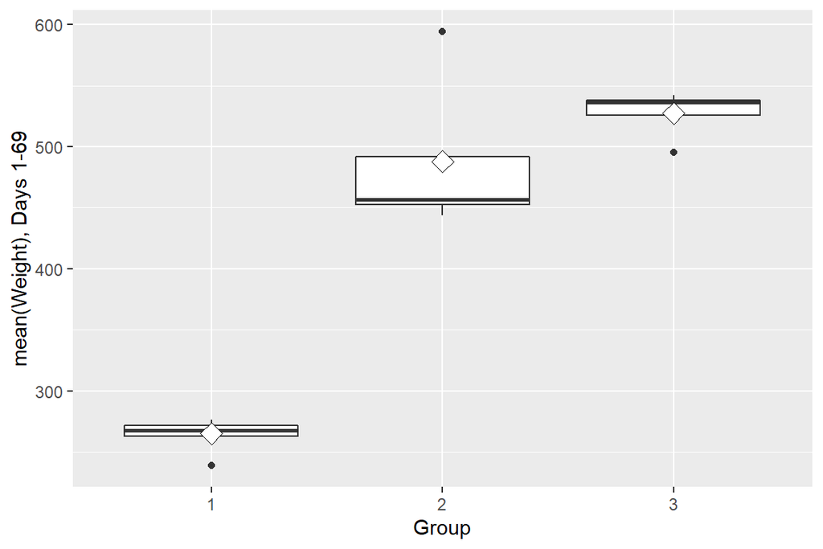

```r
ggplot(RATSLWD8, aes(x = Group, y = mean)) +
  geom_boxplot() +
  stat_summary(fun.y = "mean", geom = "point", shape=23, size=4, fill = "white") +
  scale_y_continuous(name = "mean(Weight), Days 1-69")
```

From the boxplot, we can observe 3 outliers from each group of mice. Therefore, we would have to remove the outliers.

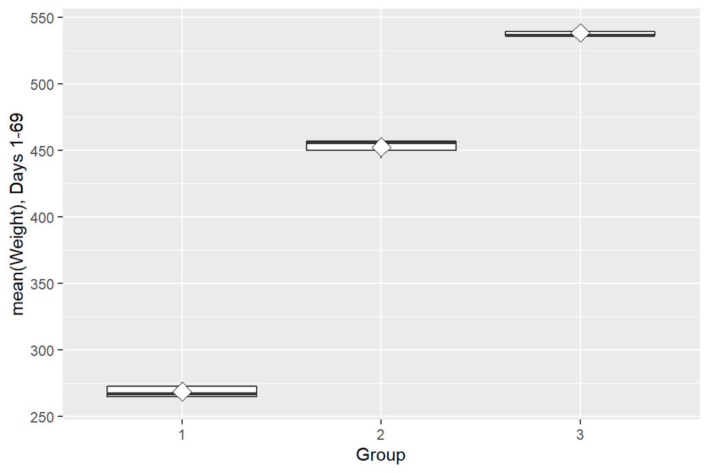

```r
RATSLWD8N<-RATSLWD8%>%
  filter(ID!=2 & ID!=12 & ID!=13)
ggplot(RATSLWD8N, aes(x = Group, y = mean)) +
  geom_boxplot() +
  stat_summary(fun.y = "mean", geom = "point", shape=23, size=4, fill = "white") +
  scale_y_continuous(name = "mean(Weight), Days 1-69")
```

After removing the outlier, we see that the variance between each point is much better. Each group has very close mean weight and thus suggest that there isn’t much changes between each mouse of the same group.

### Anova

```r
glimpse(RATSLWD8N)
```

```
## Rows: 13
## Columns: 3
## $ Group <fct> 1, 1, 1, 1, 1, 1, 1, 2, 2, 2, 3, 3, 3
## $ ID    <fct> 1, 3, 4, 5, 6, 7, 8, 9, 10, 11, 14, 15, 16
## $ mean  <dbl> 263.2, 261.7, 267.2, 270.9, 276.2, 274.6, 267.5, 443.9, 457.5...
```

```r
#Cant do t-test since we have 3 groups.

#adding day 1 as baseline
RATSLWD8N2<-RATSLWD8 %>%
  mutate(baseline=RATS$WD1)

# Fit the linear model with the mean as the response
fit <- lm(mean ~ baseline + Group , data = RATSLWD8N2)

# Compute the analysis of variance table for the fitted model with anova()
anova(fit)
```

```
## Analysis of Variance Table
##
## Response: mean
##           Df Sum Sq Mean Sq   F value   Pr(>F)
## baseline   1 253625  253625 1859.8201 1.57e-14 ***
## Group      2    879     439    3.2219  0.07586 .
## Residuals 12   1636     136
## ---
## Signif. codes:  0 '***' 0.001 '**' 0.01 '*' 0.05 '.' 0.1 ' ' 1
```

From the results of ANOVA, we can see that the baseline (in this case weight on day 1) is strongly related to the weight taken after day 1 since the P value is highly singinicant (Very small). However, there is no evidence of diet difference even after conditioning to day 1 as the P value is above 0.05 (Assuming we set at P<0.05.